# Results: Supplemented growth and bioremediation

Author

Tormey Reimer

Published

24 October 2025

**Load in all the BARRA-R2 cells being used, with their coordinates.**

```r
cell_coords <- find_read(envi_data, "R2_cell_coords") %>%
  mutate(state = factor(state, levels = states_ord)) %>%
  dplyr::select(-layer)
cells_included <- find_read(runs_data, "include")
cells_omitted <- find_read(runs_data, "omit")

totals <- cell_coords %>%
  filter(!cell_no %in% cells_omitted) %>%
  group_by(state) %>%
  reframe(cells = n())
```

**Get cell growth in ambient (normal) conditions**

```r
norm_growth_end <- file.path(runs_data, "cell_growth_end.parquet") %>%
  read_parquet(mmap = T) %>%
  merge(cell_coords, by = "cell_no")

# Total N removed at each harvest
norm_growth_end <- norm_growth_end %>%
  mutate(
    value = TN_end - TN_start,
    value = case_when(value == 0 ~ NA, T ~ value),
    month = as.factor(month(parse_date_time(start, orders = "j"))),
    species = factor(species, levels = c("armata", "taxiformis"), labels = c("A. armata", "A. taxiformis"))
  )

norm_growth_total <- norm_growth_end %>%
  mutate(
    value_na = case_when(value <= 0 ~ NA, T ~ value),
    value_0s = case_when(value <= 0 ~ 0, T ~ value)
  ) %>%
  group_by(state, species, cell_no, latitude, longitude) %>%
  reframe(
    total = sumna(value),            # good growth months may be outweighed by bad growth months
    total_na = sumna(value_na),      # bad growth months are removed
    total_na = case_when(total_na == 0 ~ NA, T ~ total_na),
    total_0s = sumna(value_0s)       # bad growth months count as zeros
  )
```

**Get cell growth in nitrogen supplemented conditions**

```r
supp_growth_end_raw <- file.path(runs_data, "cell_growth_supp_end.parquet") %>%
  read_parquet(mmap = T) %>%
  merge(cell_coords, by = "cell_no")

supp_growth_end <- supp_growth_end_raw %>%
  mutate(
    value = TN_end - TN_start,
    value = case_when(value == 0 ~ NA, T ~ value),
    month = as.factor(month(parse_date_time(start, orders = "j"))),
    species = factor(species, levels = c("armata", "taxiformis"), labels = c("A. armata", "A. taxiformis"))
  )

supp_growth_total <- supp_growth_end %>%
  mutate(
    value_na = case_when(value <= 0 ~ NA, T ~ value),
    value_0s = case_when(value <= 0 ~ 0, T ~ value)
  ) %>%
  group_by(state, species, cell_no, latitude, longitude) %>%
  reframe(
    total = sumna(value),            # good growth months may be outweighed by bad growth months
    total_na = sumna(value_na),      # bad growth months are removed
    total_na = case_when(total_na == 0 ~ NA, T ~ total_na),
    total_0s = sumna(value_0s)       # bad growth months count as zeros
  )
```

**Join them together for comparison**

```r
supplement_change <- left_join(
  norm_growth_end %>%
    select(-c("TN_start", "TN_end", "start", "value")) %>%
    rename(norm_success = success, norm_rem = TN_rem),
  supp_growth_end %>%
    select(-c("TN_start", "TN_end", "start", "value")) %>%
    rename(supp_success = success, supp_rem = TN_rem),
  by = c("state", "cell_no", "longitude", "latitude", "species", "month")
) %>%
  relocate(state, .before = cell_no) %>%
  relocate(species, .before = state) %>%
  relocate(longitude, .after = cell_no) %>%
  relocate(latitude, .after = longitude) %>%
  relocate(month, .after = latitude)

supplement_change_total <- left_join(
  norm_growth_total %>%
    rename(norm_total = total, norm_total_na = total_na, norm_total_0s = total_0s),
  supp_growth_total %>%
    rename(supp_total = total, supp_total_na = total_na, supp_total_0s = total_0s),
  by = c("state", "cell_no", "longitude", "latitude", "species")
)
```

# Supplemented success change

Provide summaries of the changes in success (ie whether the modelled seaweed was able to successfully growth at all within a cell) between normal and supplemented growth.

**How many/what proportion of cells became successful in each month (and overall) because of supplementation**

```r
# Which cells changed in success (per month)
norm_success <- supplement_change %>%
  filter(norm_success) %>%
  group_by(species, month) %>%
  reframe(
    norm_success_cells = n(),
    perc_total_cells = 100*n()/11748
  )
success_change <- supplement_change %>%
  filter(supp_success != norm_success) %>%
  group_by(species, month) %>%
  reframe(success_change_cells = n())

norm_success %>%
  left_join(success_change, by = c("species", "month")) %>%
  mutate(
    percdiff_normal_change = 100*success_change_cells/norm_success_cells,
    perc_total_change = 100*success_change_cells/11748
  ) %>%
  select(-norm_success_cells, -success_change_cells) %>%
  print(n = 24)
```

```
# A tibble: 24 × 5
   species       month perc_total_cells percdiff_normal_change perc_total_change
   <fct>         <fct>            <dbl>                  <dbl>             <dbl>
 1 A. armata     1                 40.1                   4.12             1.65
 2 A. armata     2                 39.0                   1.62             0.630
 3 A. armata     3                 38.3                   2.83             1.08
 4 A. armata     4                 39.6                   4.70             1.86
 5 A. armata     5                 41.4                   7.26             3.00
 6 A. armata     6                 46.2                   9.31             4.30
 7 A. armata     7                 51.4                  11.9              6.12
 8 A. armata     8                 54.7                   7.16             3.92
 9 A. armata     9                 54.1                   4.80             2.60
10 A. armata     10                49.6                   4.10             2.03
11 A. armata     11                48.1                   3.27             1.57
12 A. armata     12                44.5                   4.63             2.06
13 A. taxiformis 1                 47.5                  29.7             14.1
14 A. taxiformis 2                 53.1                  15.9              8.47
15 A. taxiformis 3                 50.7                  21.5             10.9
16 A. taxiformis 4                 50.0                  23.6             11.8
17 A. taxiformis 5                 67.1                  18.7             12.6
18 A. taxiformis 6                 63.5                  14.6              9.26
19 A. taxiformis 7                 58.2                  13.0              7.58
20 A. taxiformis 8                 56.5                  12.0              6.76
21 A. taxiformis 9                 57.6                   8.87             5.11
22 A. taxiformis 10                54.7                  14.4              7.91
23 A. taxiformis 11                39.1                  42.6             16.7
24 A. taxiformis 12                40.8                  32.9             13.4
```

**How many/what proportion of cells became successful in each month (and overall) because of supplementation**

```r
# Which cells changed in success (overall)
norm_success <- supplement_change %>%
  filter(norm_success) %>%
  group_by(species) %>%
  reframe(
    norm_success_cells = n(),
    perc_total_cells = 100*n()/(12*11748)
  )
success_change <- supplement_change %>%
  filter(supp_success != norm_success) %>%
  group_by(species) %>%
  reframe(success_change_cells = n())

norm_success %>%
  left_join(success_change, by = c("species")) %>%
  mutate(
    percdiff_normal_ch = 100*success_change_cells/norm_success_cells,
    perc_total_ch = 100*success_change_cells/(11748*12)
  ) %>%
  select(-norm_success_cells, -success_change_cells)
```

```
# A tibble: 2 × 4
  species       perc_total_cells percdiff_normal_ch perc_total_ch
  <fct>                    <dbl>              <dbl>         <dbl>
1 A. armata                 45.6               5.64          2.57
2 A. taxiformis             53.2              19.5          10.4
```

```r
library(terra)

rdata_norm <- norm_growth_end %>%
  select(cell_no, species, success, longitude, latitude, month) %>%
  group_by(species, cell_no, longitude, latitude) %>%
  reframe(
    success = as.numeric(any(success)),
    success = case_when(success == 0 ~ NA, T ~ 1)
  ) %>%
  filter(species != "A. armata")

rdata_supp <- supp_growth_end %>%
  select(cell_no, species, success, longitude, latitude, month) %>%
  group_by(species, cell_no, longitude, latitude) %>%
  reframe(
    success = as.numeric(any(success)),
    success = case_when(success == 0 ~ NA, T ~ 1)
  ) %>%
  filter(species != "A. armata")

r_template <- rast(
  extent = ext(c(min(rdata_norm$longitude), max(rdata_norm$longitude),
                 min(rdata_norm$latitude), max(rdata_norm$latitude))),
  resolution = 0.12
)

r <- rasterize(rdata_norm[, c("longitude", "latitude")], r_template, values = rdata_norm$success)
r_area <- cellSize(r, unit = "km")
r_area <- mask(r_area, r)
area_norm_success <- global(r_area, fun = sumna)[[1]]

r <- rasterize(rdata_supp[, c("longitude", "latitude")], r_template, values = rdata_supp$success)
r_area <- cellSize(r, unit = "km")
r_area <- mask(r_area, r)
area_supp_success <- global(r_area, fun = sumna)[[1]]

area_supp_success-area_norm_success
100*(area_supp_success-area_norm_success)/area_norm_success
```

[output not shown]

**Find out where cells changed from failure to success under supplemented conditions**

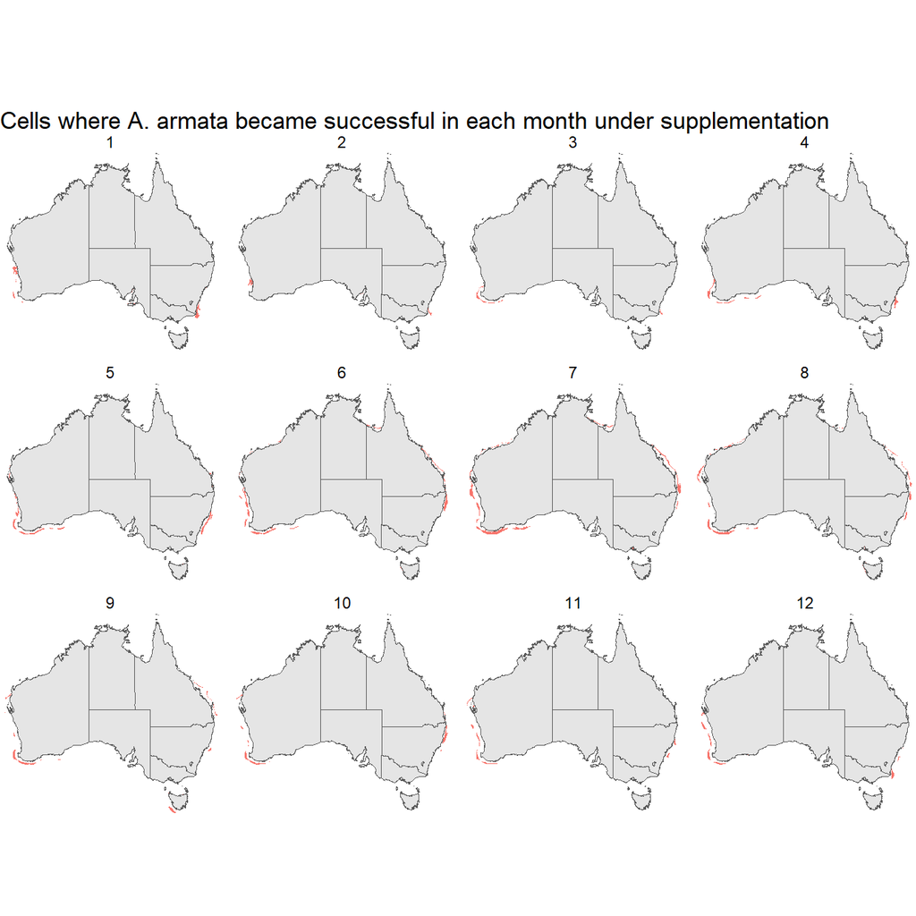

```r
supplement_change %>%
  mutate(success_change = case_when(supp_success != norm_success ~ T, T ~ F)) %>%
  filter(success_change & species == "A. armata") %>%
  ggplot(aes(x = longitude, y = latitude, fill = success_change)) +
  geom_tile() +
  geom_sf(data = ozmap_data(data = "states"), inherit.aes = F) +
  coord_sf(
    xlim = c(111.5, 155),
    ylim = c(-44.5, -8.5),
    expand = F
  ) +
  theme_void() + theme(legend.position = "none") +
  facet_wrap(facets = vars(month), nrow = 3) +
  ggtitle("Cells where A. armata became successful in each month under supplementation")
```

**Find out where cells changed from failure to success under supplemented conditions**

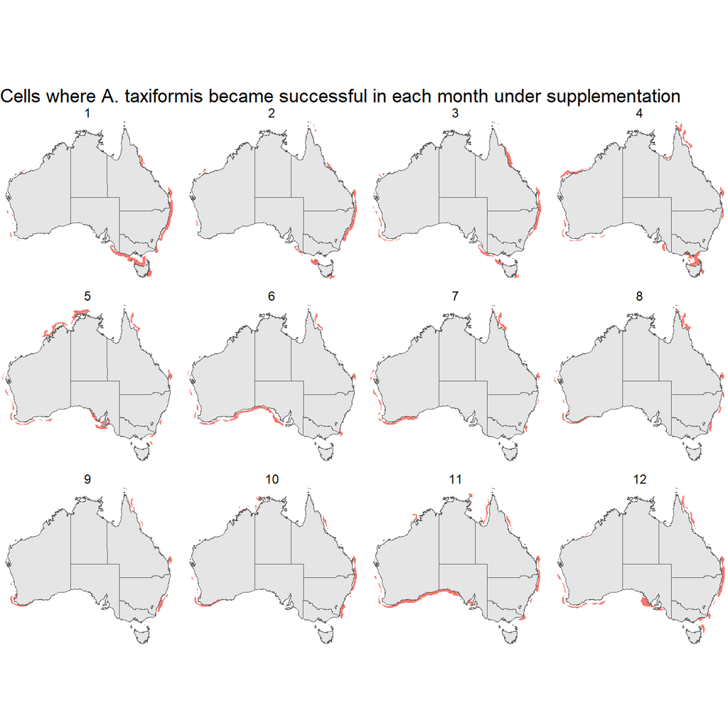

```r
supplement_change %>%
  mutate(success_change = case_when(supp_success != norm_success ~ T, T ~ F)) %>%
  filter(success_change & species == "A. taxiformis") %>%
  ggplot(aes(x = longitude, y = latitude, fill = success_change)) +
  geom_tile() +
  geom_sf(data = ozmap_data(data = "states"), inherit.aes = F) +
  coord_sf(
    xlim = c(111.5, 155),
    ylim = c(-44.5, -8.5),
    expand = F
  ) +
  theme_void() + theme(legend.position = "none") +
  facet_wrap(facets = vars(month), nrow = 3) +
  ggtitle("Cells where A. taxiformis became successful in each month under supplementation")
```

# Supplemented nitrogen removal

**Differences in nitrogen removed because of supplementation**

```r
rem_diff_total <- supplement_change %>%
  select(-contains("success")) %>%
  mutate(
    norm_rem = case_when(norm_rem <= 0 ~ NA, T ~ norm_rem),
    supp_rem = case_when(supp_rem <= 0 ~ NA, T ~ supp_rem),
    rem_diff = supp_rem - norm_rem
  )

# Show difference in nitrogen removed per month (all cells)
rem_diff_total %>%
  group_by(species, month) %>%
  reframe(
    norm_rem = sumna(norm_rem),
    supp_rem = sumna(supp_rem),
    rem_diff = sumna(rem_diff)/norm_rem,
    perc_rem_diff = 100*rem_diff
  ) %>%
  print(n = 24)
```

```
# A tibble: 24 × 6
   species       month norm_rem supp_rem rem_diff perc_rem_diff
   <fct>         <fct>    <dbl>    <dbl>    <dbl>         <dbl>
 1 A. armata     1      308334. 3751458.    10.9          1092.
 2 A. armata     2      449571. 3454574.     6.67          667.
 3 A. armata     3      550572. 3693484.     5.59          559.
 4 A. armata     4      649378. 3723695.     4.59          459.
 5 A. armata     5      589669. 3981902.     5.48          548.
 6 A. armata     6      603265. 4263608.     5.76          576.
 7 A. armata     7      579579. 4914718.     6.90          690.
 8 A. armata     8      566690. 5042049.     7.50          750.
 9 A. armata     9      577169. 4765461.     7.02          702.
10 A. armata     10     556714. 4564296.     6.96          696.
11 A. armata     11     646249. 4399235.     5.64          564.
12 A. armata     12     452046. 4203121.     7.97          797.
13 A. taxiformis 1      338957. 4748013.    11.0          1104.
14 A. taxiformis 2      502528. 4683176.     7.54          754.
15 A. taxiformis 3      440637. 4899912.     8.90          890.
16 A. taxiformis 4      439204. 4602396.     8.66          866.
17 A. taxiformis 5      524051. 6093775.     9.68          968.
18 A. taxiformis 6      568102. 6060998.     9.10          910.
19 A. taxiformis 7      399682. 5849216.    12.6          1255.
20 A. taxiformis 8      372253. 5628894.    13.1          1308.
21 A. taxiformis 9      453667. 5400841.    10.4          1044.
22 A. taxiformis 10     449672. 5109480.     9.53          953.
23 A. taxiformis 11     363262. 3787290.     8.01          801.
24 A. taxiformis 12     300443. 4024356.    10.3          1031.
```

**Differences in nitrogen removed because of supplementation**

```r
# Show difference in nitrogen removed (overall)
supplement_change_total %>%
  mutate(
    rem_diff = supp_total_0s-norm_total_0s,
    rem_diff = case_when(rem_diff <= 0 ~ NA, T ~ rem_diff)
  ) %>%
  group_by(species) %>%
  reframe(
    rem_diff = sumna(rem_diff),
    rem_diff_kg = rem_diff %>% set_units("mg") %>% set_units("kg"),
    norm_total_na = sumna(norm_total_na),
    supp_total_na = sumna(supp_total_na),
    prop_rem_diff = rem_diff/norm_total_na,
    perc_rem_diff = 100*prop_rem_diff
  )
```

[output not shown]

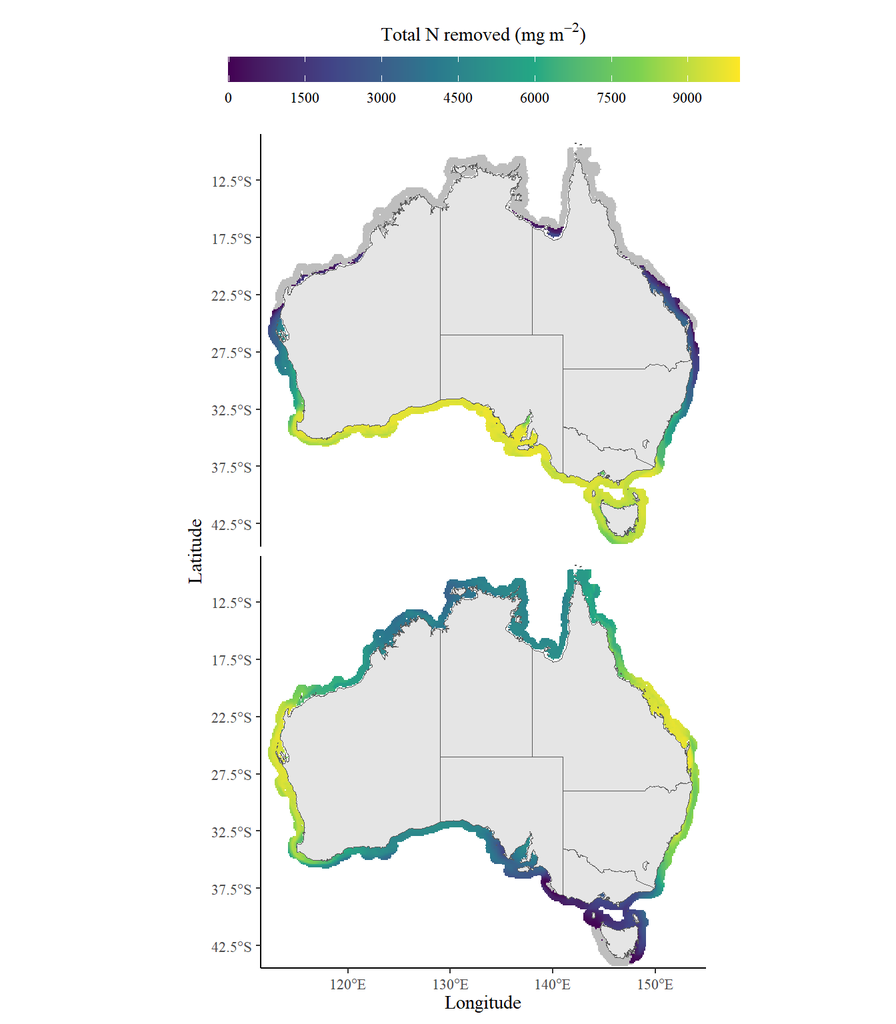

Figure 1: Total nitrogen removed by *A. armata* (top) and _A. taxiformis (bottom) across the entire year under supplemented conditions.

```r
supp_growth_total %>%
  ggplot(aes(x = longitude, y = latitude, fill = total_na)) +
  geom_tile() +
  geom_sf(data = ozmap_data(data = "states"), inherit.aes = F) +
  coord_sf(xlim = c(111.5, 155), ylim = c(-44.5, -8.5), expand = F) +
  scale_x_continuous(breaks = seq(100, 160, 10)) +
  scale_y_continuous(breaks = seq(-2.5, -45, -5)) +
  scale_fill_viridis_c(
    limits = c(0, 10000),
    breaks = seq(0, 10000, 1500),
    na.value = "grey",
    guide = guide_colorbar(
      title = expression("Total N removed (mg m"^-2 * ")"),
      barheight = 1,
      barwidth = 20,
      title.position = "top",
      title.hjust = 0.5
    )
  ) +
  labs(x = "Longitude", y = "Latitude") +
  prettyplot() +
  theme(legend.position = "top", strip.text = element_blank(), strip.background = element_blank()) +
  facet_grid(rows = vars(species))
```

## Comparing normal and supplemented removal

```r
all_growth_total <- rbind(
  norm_growth_total %>% mutate(scenario = "norm_conditions"),
  supp_growth_total %>% mutate(scenario = "supp_conditions")
)

# hist(all_growth_total$total_na[all_growth_total$scenario == "norm_conditions"])
# hist(all_growth_total$total_na[all_growth_total$scenario != "norm_conditions"])
minna(all_growth_total$total_na)
```

```
[1] 0.325727
```

```r
maxna(all_growth_total$total_na)
```

```
[1] 9873.595
```

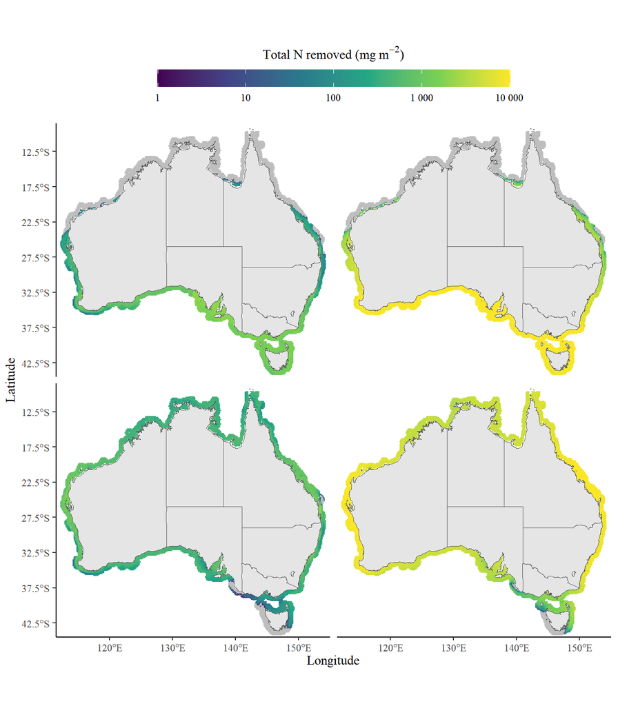

Total nitrogen removed by *A. armata* (top) and _A. taxiformis (bottom) across the entire year under normal conditions (left) and supplemented conditions (right).

```r
all_growth_total %>%
  ggplot(aes(x = longitude, y = latitude, fill = total_na)) +
  geom_tile() +
  geom_sf(data = ozmap_data(data = "states"), inherit.aes = F) +
  coord_sf(xlim = c(111.5, 155), ylim = c(-44.5, -8.5), expand = F) +
  scale_x_continuous(breaks = seq(100, 160, 10)) +
  scale_y_continuous(breaks = seq(-2.5, -45, -5)) +
  scale_fill_viridis_c(
    limits = c(1, 10000),
    labels = scales::label_number(),
    trans = "log10",
    na.value = "grey",
    guide = guide_colorbar(
      title = expression("Total N removed (mg m"^-2 * ")"),
      barheight = 1,
      barwidth = 20,
      title.position = "top",
      title.hjust = 0.5
    )
  ) +
  labs(x = "Longitude", y = "Latitude") +
  facet_grid(rows = vars(species), cols = vars(scenario)) +
  prettyplot() +
  theme(legend.position = "top", strip.text = element_blank(), strip.background = element_blank())
```

## Supplemented removed OF supplementation

Overall, the supplemented growth had an extra 10uM of nitrogen per day, or an extra 3650 uM per year. How much of that was actually removed by supplemented growth?

```r
supplementation <- set_units(3650, "umol L-1")
supplementation <- supplementation %>% set_units("mg m-3")
supplementation <- (supplementation * set_units(5.5, "m")) %>% drop_units()

rem_diff_ofsupp <- rem_diff_total %>%
  select(-norm_rem, -rem_diff) %>%
  group_by(species, state, cell_no, longitude, latitude) %>%
  reframe(supp_rem = sumna(supp_rem)) %>%
  mutate(
    supp_rem = supp_rem/supplementation,
    # supp_rem = case_when(supp_rem <= 0 ~ NA, T ~ supp_rem)
  )

rem_diff_ofsupp %>%
  group_by(species) %>%
  reframe(
    supp_rem_mean = 100*meanna(supp_rem),
    supp_rem_max = 100*maxna(supp_rem)
  )
```

[output not shown]

# Monthly supplemented growth results

**Get mean nitrogen removed per each state/month**

```r
supp_growth_month_arma <- supp_growth_end %>%
  filter(success & species == "A. armata") %>%
  group_by(species, state, month) %>%
  reframe(
    mean = meanna(value) %>% set_units("mg m-2"),
    sd = sdna(value) %>% set_units("mg m-2")
  )

supp_growth_month_arma %>%
  select(-sd) %>%
  pivot_wider(names_from = state, values_from = mean) %>%
  arrange(month)
```

```
# A tibble: 12 × 10
   species   month      NTE      QLD      NSW      SAU     TAS   VIC   WAN   WAS
   <fct>     <fct> [mg/m^2] [mg/m^2] [mg/m^2] [mg/m^2] [mg/m^… [mg/… [mg/… [mg/…
 1 A. armata 1          NA      NA       352.     789.    802.  798.  NA    735.
 2 A. armata 2          NA      NA       507.     754.    765.  762.  NA    711.
 3 A. armata 3          NA      NA       522.     811.    816.  814.  NA    774.
 4 A. armata 4          NA     364.      523.     796.    786.  789.  NA    740.
 5 A. armata 5          NA     350.      641.     808.    779.  773.  43.6  748.
 6 A. armata 6          NA     491.      669.     766.    746.  759. 307.   718.
 7 A. armata 7         344.    614.      748.     773.    737.  748. 561.   733.
 8 A. armata 8          NA     707.      754.     771.    669.  726. 436.   769.
 9 A. armata 9          NA     629.      734.     769.    608.  706. 526.   772.
10 A. armata 10         NA     174.      699.     805.    682.  766. 486.   787.
11 A. armata 11         NA      26.5     709.     797.    739.  777. 103.   740.
12 A. armata 12         NA      NA       675.     802.    791.  800.  NA    733.
```

**Get mean nitrogen removed per each state/month**

```r
supp_growth_month_taxi <- supp_growth_end %>%
  filter(success & species != "A. armata") %>%
  group_by(species, state, month) %>%
  reframe(
    mean = meanna(value) %>% set_units("mg m-2"),
    sd = sdna(value) %>% set_units("mg m-2")
  )

supp_growth_month_taxi %>%
  select(-sd) %>%
  pivot_wider(names_from = state, values_from = mean) %>%
  arrange(month)
```

```
# A tibble: 12 × 10
   species       month      NTE      QLD      NSW    SAU   TAS   VIC   WAN   WAS
   <fct>         <fct> [mg/m^2] [mg/m^2] [mg/m^2] [mg/m… [mg/… [mg/… [mg/… [mg/…
 1 A. taxiformis 1        430.      681.     673.  662.  401.  565.   681.  751.
 2 A. taxiformis 2        727.      642.     647.  666.  485.  608.   629.  728.
 3 A. taxiformis 3        646.      632.     719.  695.  510.  583.   686.  781.
 4 A. taxiformis 4        717.      667.     729.  646.  217.  313.   447.  759.
 5 A. taxiformis 5        541.      763.     744.  394.   57.6 384.   599.  746.
 6 A. taxiformis 6        786.      779.     696.   97.6  NA    95.7  785.  620.
 7 A. taxiformis 7        817.      794.     634.   NA    NA    NA    814.  621.
 8 A. taxiformis 8        812.      791.     578.   NA    NA    NA    811.  633.
 9 A. taxiformis 9        785.      772.     541.  556.   NA    NA    785.  603.
10 A. taxiformis 10       630.      780.     603.  600.   NA    40.0  710.  610.
11 A. taxiformis 11        65.9     674.     663.  257.   28.4 258.   662.  495.
12 A. taxiformis 12        NA       662.     695.  461.  170.  377.   737.  686.
```

```r
plot_data <- rbind(supp_growth_month_arma, supp_growth_month_taxi) %>%
  mutate(
    mean = drop_units(mean),
    sd = drop_units(sd),
    mean = case_when(is.na(mean) ~ 0, T ~ mean),
    sd = case_when(sd > mean ~ mean, is.na(sd) ~ 0, T ~ sd),
    state = factor(state, levels = states_ord, labels = states_lng),
    month = as.integer(month)
  )

plot_data %>%
  ggplot(aes(
      x = month, y = mean, ymin = mean - sd, ymax = mean + sd,
      color = state, fill = state, linetype = species
  )) +
  geom_line(linewidth = 0.75) +
  geom_ribbon(alpha = 0.25, linewidth = 0.25) +
  facet_wrap(facets = vars(state), ncol = 2) +
  # scale_y_continuous(breaks = seq(0, 150, 25), limits = c(0, 175), expand = c(0,0)) +
  scale_color_manual(values = states_pal) +
  scale_fill_manual(values = states_pal) +
  env_plot() +
  labs(x = "Day of the year", y = expression("Total N removed (mg m"^-2 *")"))
```

[output not shown]